# Assignment #2

Sara Bayat

06 November 2023

```r
knitr::opts_chunk$set(echo = TRUE)
knitr::opts_chunk$set(warning = FALSE, message = FALSE)
library(officer)
ft <- officer::fp_text(shading.color = "yellow")
word_spec <- function(x, prop = ft) ftext(text = toString(x) ,prop =  ft)
```

# 1 Interducing the Data

In order to showcase the proficiency of unsupervised techniques, the wine dataset, which has not any missing value, has been utilized, which comprises three diverse cultivars, each with thirteen distinct features that represent varying quantities of components. Below, you can find a detailed statistical summary for each variable. As we use normalized values for principal component analysis (PCA), we utilize the function *scale()* to standardize our data and ensure accurate analysis.

```r
# set work directory
setwd("E:/Carleton - Master/Fall 2023 - semester 1/Data Mining/Data Mining - Dr. Mills/Assignment #2")
# read data file
winedata <- read.csv("wine.data.txt",sep=",", header=F)
names(winedata) <- c("Cvs", "Alcohol", "Malic acid","Ash", "Alcalinity of ash",
                    "Magnesium", "Total phenols", "Flavanoids", "Nonflavanoid phenols",
                    "Proanthocyanins", "Color intensity", "Hue",
                    "OD280/OD315 of diluted wines", "Proline")
head(winedata)
```

|  | Cvs | Alcohol | Malic acid | Ash | Alcalinity of ash | Magnesium | Total phenols | Flavanoids | Nonflavanoid phenols | Proanthocyanins | Color intensity | Hue | OD280/OD315 of diluted wines | Proline |
| --- | --- | --- | --- | --- | --- | --- | --- | --- | --- | --- | --- | --- | --- | --- |
| 1 | 1 | 14.23 | 1.71 | 2.43 | 15.6 | 127 | 2.80 | 3.06 | 0.28 | 2.29 | 5.64 | 1.04 | 3.92 | 1065 |
| 2 | 1 | 13.20 | 1.78 | 2.14 | 11.2 | 100 | 2.65 | 2.76 | 0.26 | 1.28 | 4.38 | 1.05 | 3.40 | 1050 |
| 3 | 1 | 13.16 | 2.36 | 2.67 | 18.6 | 101 | 2.80 | 3.24 | 0.30 | 2.81 | 5.68 | 1.03 | 3.17 | 1185 |
| 4 | 1 | 14.37 | 1.95 | 2.50 | 16.8 | 113 | 3.85 | 3.49 | 0.24 | 2.18 | 7.80 | 0.86 | 3.45 | 1480 |
| 5 | 1 | 13.24 | 2.59 | 2.87 | 21.0 | 118 | 2.80 | 2.69 | 0.39 | 1.82 | 4.32 | 1.04 | 2.93 | 735 |
| 6 | 1 | 14.20 | 1.76 | 2.45 | 15.2 | 112 | 3.27 | 3.39 | 0.34 | 1.97 | 6.75 | 1.05 | 2.85 | 1450 |

```r
colSums(is.na(winedata))
```

```
##                          Cvs                      Alcohol
##                            0                            0
##                   Malic acid                          Ash
##                            0                            0
##            Alcalinity of ash                    Magnesium
##                            0                            0
##                Total phenols                   Flavanoids
##                            0                            0
##         Nonflavanoid phenols              Proanthocyanins
##                            0                            0
##              Color intensity                          Hue
##                            0                            0
## OD280/OD315 of diluted wines                      Proline
##                            0                            0
```

```r
summary(winedata)
```

```
##       Cvs           Alcohol        Malic acid         Ash
##  Min.   :1.000   Min.   :11.03   Min.   :0.740   Min.   :1.360
##  1st Qu.:1.000   1st Qu.:12.36   1st Qu.:1.603   1st Qu.:2.210
##  Median :2.000   Median :13.05   Median :1.865   Median :2.360
##  Mean   :1.938   Mean   :13.00   Mean   :2.336   Mean   :2.367
##  3rd Qu.:3.000   3rd Qu.:13.68   3rd Qu.:3.083   3rd Qu.:2.558
##  Max.   :3.000   Max.   :14.83   Max.   :5.800   Max.   :3.230
##  Alcalinity of ash   Magnesium      Total phenols     Flavanoids
##  Min.   :10.60     Min.   : 70.00   Min.   :0.980   Min.   :0.340
##  1st Qu.:17.20     1st Qu.: 88.00   1st Qu.:1.742   1st Qu.:1.205
##  Median :19.50     Median : 98.00   Median :2.355   Median :2.135
##  Mean   :19.49     Mean   : 99.74   Mean   :2.295   Mean   :2.029
##  3rd Qu.:21.50     3rd Qu.:107.00   3rd Qu.:2.800   3rd Qu.:2.875
##  Max.   :30.00     Max.   :162.00   Max.   :3.880   Max.   :5.080
##  Nonflavanoid phenols Proanthocyanins Color intensity       Hue
##  Min.   :0.1300       Min.   :0.410   Min.   : 1.280   Min.   :0.4800
##  1st Qu.:0.2700       1st Qu.:1.250   1st Qu.: 3.220   1st Qu.:0.7825
##  Median :0.3400       Median :1.555   Median : 4.690   Median :0.9650
##  Mean   :0.3619       Mean   :1.591   Mean   : 5.058   Mean   :0.9574
##  3rd Qu.:0.4375       3rd Qu.:1.950   3rd Qu.: 6.200   3rd Qu.:1.1200
##  Max.   :0.6600       Max.   :3.580   Max.   :13.000   Max.   :1.7100
##  OD280/OD315 of diluted wines    Proline
##  Min.   :1.270                Min.   : 278.0
##  1st Qu.:1.938                1st Qu.: 500.5
##  Median :2.780                Median : 673.5
##  Mean   :2.612                Mean   : 746.9
##  3rd Qu.:3.170                3rd Qu.: 985.0
##  Max.   :4.000                Max.   :1680.0
```

```r
# normalized data
wine_s <- scale(winedata[,2:14])
head(wine_s)
```

```
##        Alcohol  Malic acid        Ash Alcalinity of ash  Magnesium
## [1,] 1.5143408 -0.56066822  0.2313998        -1.1663032 1.90852151
## [2,] 0.2455968 -0.49800856 -0.8256672        -2.4838405 0.01809398
## [3,] 0.1963252  0.02117152  1.1062139        -0.2679823 0.08810981
## [4,] 1.6867914 -0.34583508  0.4865539        -0.8069748 0.92829983
## [5,] 0.2948684  0.22705328  1.8352256         0.4506745 1.27837900
## [6,] 1.4773871 -0.51591132  0.3043010        -1.2860793 0.85828399
##      Total phenols Flavanoids Nonflavanoid phenols Proanthocyanins
## [1,]     0.8067217  1.0319081           -0.6577078       1.2214385
## [2,]     0.5670481  0.7315653           -0.8184106      -0.5431887
## [3,]     0.8067217  1.2121137           -0.4970050       2.1299594
## [4,]     2.4844372  1.4623994           -0.9791134       1.0292513
## [5,]     0.8067217  0.6614853            0.2261576       0.4002753
## [6,]     1.5576991  1.3622851           -0.1755994       0.6623487
##      Color intensity        Hue OD280/OD315 of diluted wines     Proline
## [1,]       0.2510088  0.3611585                    1.8427215  1.01015939
## [2,]      -0.2924962  0.4049085                    1.1103172  0.96252635
## [3,]       0.2682629  0.3174085                    0.7863692  1.39122370
## [4,]       1.1827317 -0.4263410                    1.1807407  2.32800680
## [5,]      -0.3183774  0.3611585                    0.4483365 -0.03776747
## [6,]       0.7298108  0.4049085                    0.3356589  2.23274072
```

# 2 Principal Component Analysis

## 2.1 Review

When examining data using a scatterplot matrix, the only visible structure is the relationship between two variables as seen from the original coordinate axes. In the event that all scatterplots involving a particular variable appear as horizontal or vertical straight lines, we can conclude that it is unnecessary to use that variable in modeling the data. Similarly, we may observe a comparable behavior for linear combinations of variables when the data is rotated. PCA is a method that allows us to identify such structure.

## 2.2 PCA

The data was analyzed using a method that generated 13 principal components called PC1 to PC13. Each of these components plays a crucial role in explaining a certain percentage of the variance present in the dataset. The **Proportion of Variance** section reveals that the first principal component (PC1) is responsible for explaining almost 36% of the total variance while the second component explains 19.21% of the total variance. The third component explains approximately 11% and so on.

The **Cumulative Proportion** of PC1 to PC5 accounts for just over 80% of the total variance present in the dataset. This implies that the first five principal components are capable of accurately representing the data. Therefore, it can be concluded that these components are highly relevant and critical in understanding the dataset.

```r
library(stats)
library(factoextra)
wine.pc <- princomp(wine_s)
summary(wine.pc)
```

```
## Importance of components:
##                           Comp.1    Comp.2    Comp.3    Comp.4     Comp.5
## Standard deviation     2.1631951 1.5757366 1.1991447 0.9559347 0.92110518
## Proportion of Variance 0.3619885 0.1920749 0.1112363 0.0706903 0.06563294
## Cumulative Proportion  0.3619885 0.5540634 0.6652997 0.7359900 0.80162293
##                            Comp.6     Comp.7     Comp.8     Comp.9    Comp.10
## Standard deviation     0.79878171 0.74022473 0.58867607 0.53596364 0.49949266
## Proportion of Variance 0.04935823 0.04238679 0.02680749 0.02222153 0.01930019
## Cumulative Proportion  0.85098116 0.89336795 0.92017544 0.94239698 0.96169717
##                           Comp.11    Comp.12     Comp.13
## Standard deviation     0.47383559 0.40966094 0.320619963
## Proportion of Variance 0.01736836 0.01298233 0.007952149
## Cumulative Proportion  0.97906553 0.99204785 1.000000000
```

## 2.3 Five First PCs

```r
wine.5pc <- wine.pc$scores[,1:5]
head(wine.5pc)
```

```
##        Comp.1     Comp.2     Comp.3     Comp.4     Comp.5
## [1,] 3.307421  1.4394023  0.1652728  0.2150246 -0.6910933
## [2,] 2.203250 -0.3324551  2.0207571  0.2905387  0.2569299
## [3,] 2.509661  1.0282507 -0.9800541 -0.7228632  0.2503270
## [4,] 3.746497  2.7486184  0.1756962 -0.5663856  0.3109644
## [5,] 1.006070  0.8673840 -2.0209873  0.4086131 -0.2976180
## [6,] 3.041674  2.1164309  0.6276254  0.5141870  0.6302409
```

The first principal component, has a moderate correlation with four variables. However, these correlation values are lower than 0.5, indicating a relatively weak relationship. The PC1 is relatively influenced by V7, V8, V13, and V10, as they tend to increase together, which means that when one of these variables increases or decreases, the others follow a similar pattern. The remaining variables have a weak correlation with PCA 1, with most correlation values being less than 0.3, that implies that the first principal component has little or no relationship with the other variables.

```r
wine.pc$rotation[,1:5]
```

[output not shown]

```r
wine.pc
```

```
## Call:
## princomp(x = wine_s)
##
## Standard deviations:
##    Comp.1    Comp.2    Comp.3    Comp.4    Comp.5    Comp.6    Comp.7    Comp.8
## 2.1631951 1.5757366 1.1991447 0.9559347 0.9211052 0.7987817 0.7402247 0.5886761
##    Comp.9   Comp.10   Comp.11   Comp.12   Comp.13
## 0.5359636 0.4994927 0.4738356 0.4096609 0.3206200
##
##  13  variables and  178 observations.
```

# 3 Visualization

## 3.1 Scree plot

A scree plot can be a useful tool to gain insights into the underlying structure of the data. By visualizing the eigenvalues, it is possible to get a better understanding of the number of significant principal components and the amount of variance explained by each one. The percentage of variances explained by each principal component can be easily determined and displayed on the scree plot for further analysis.

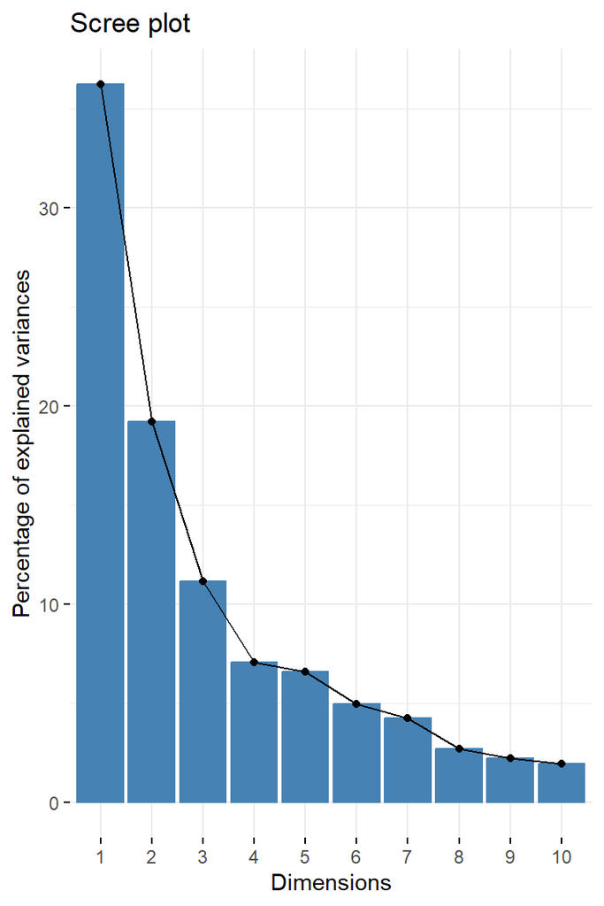

Scree Plot

```r
fviz_eig(wine.pc)
```

## 3.2 Graph of Variables

In a **graph of variables**, the positioning of each variable can give us valuable insights into their relationships. When two variables are positively correlated, they tend to move in the same direction as each other. This results in their respective positions on the graph being closer together. Conversely, when two variables are negatively correlated, they move in opposite directions and are positioned farther apart on the graph. In the dataset, we can observe that Variable10 and Variable7 have a direct relationship, meaning when one variable increases, so does the other. On the other hand, Variable3 and Variable12 have an inverse relationship, indicating that as one variable increases, the other decreases.

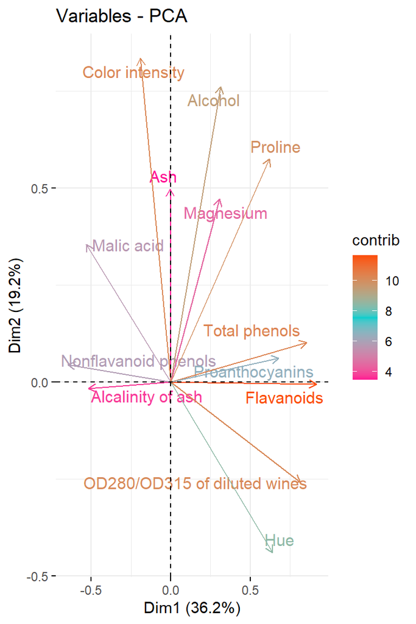

Graph of Variables

```r
fviz_pca_var(wine.pc,
             col.var = "contrib", # Color by contributions to the PC
             gradient.cols = c("deeppink1", "cyan3", "#FC4E07"),
             repel = TRUE     # Avoid text overlapping
             )
```

## 3.3 Biplot

A biplot is a combination of a score plot and a loadings (eigenvalues) plot, which are two common plots used in principal component analysis. Although these plots are on different scales, it is possible to rescale them and overlay them on a single plot. By selecting the appropriate scaling, the biplot can accurately show the relationship between variables or observations. Additionally, it can also provide approximate relationships between variables and observations.

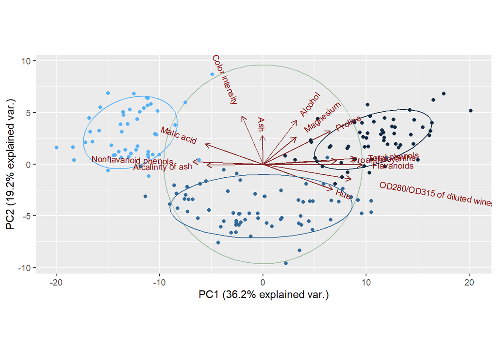

Biplot

```r
library(devtools)
#install_github("vqv/ggbiplot")
library(ggbiplot)
ggbiplot(wine.pc,
              obs.scale = 3,
              var.scale = 3,
              groups = winedata[,1],
              ellipse = TRUE,
              circle = TRUE,
              ellipse.prob = .68) +
  theme(legend.position = "none")
```

## 3.4 Scatterplot Matrix

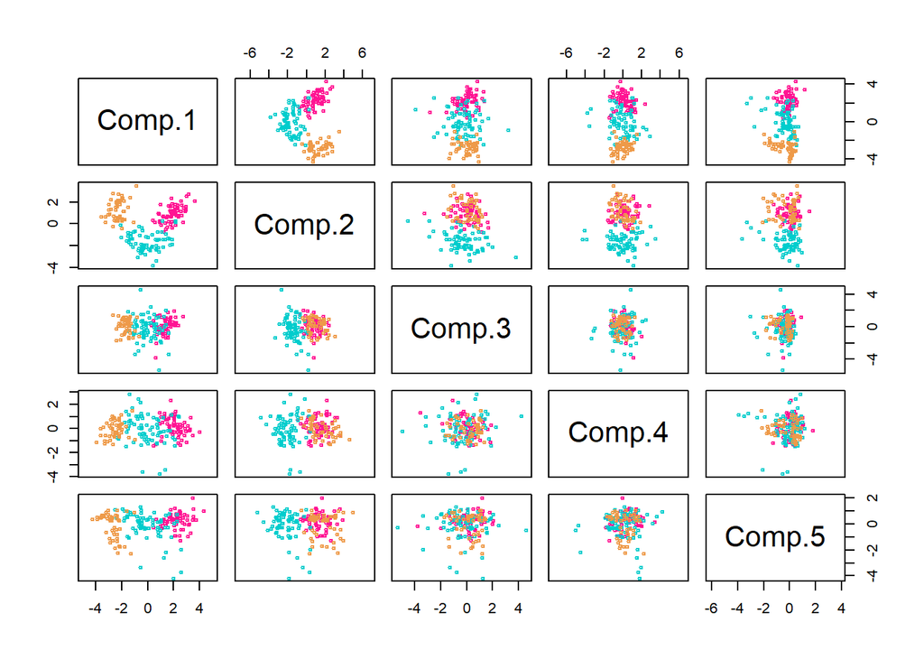

Scatter Plot of First 5 PCs - PCA

```r
pairs(wine.pc$scores[,1:5],
      col=c("deeppink1", "cyan3", "tan2")[winedata[,1]], asp=1, pch = 21, cex=.5)
```

## 3.5 3D Scatterplot

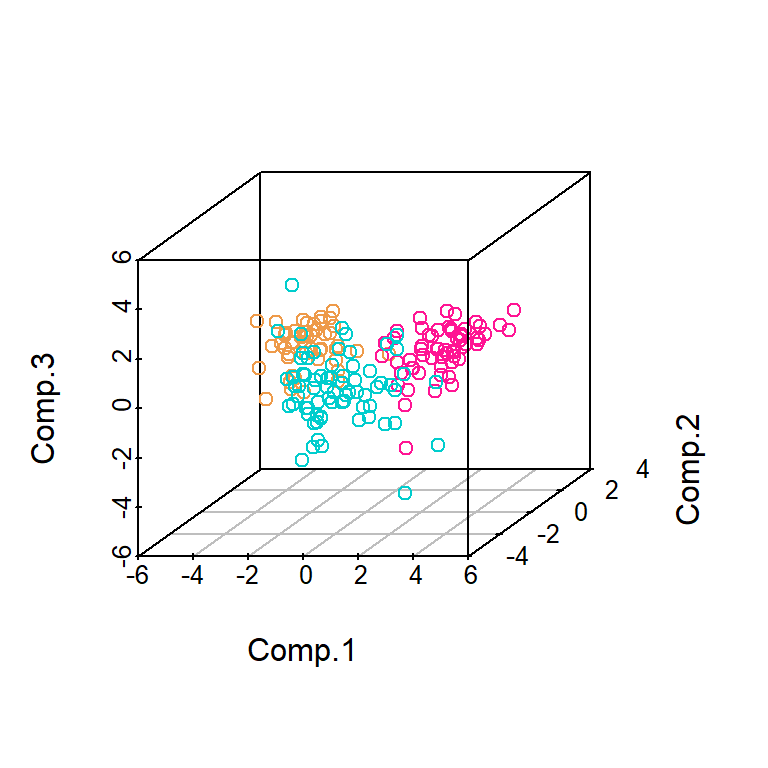

3D Scatter Plot of PCs 1, 2 and 3

```r
library(scatterplot3d)
d1 <- scatterplot3d(wine.pc$scores[,c(1,2,3)],
              color=c("deeppink1", "cyan3", "tan2")[winedata[,1]])
```

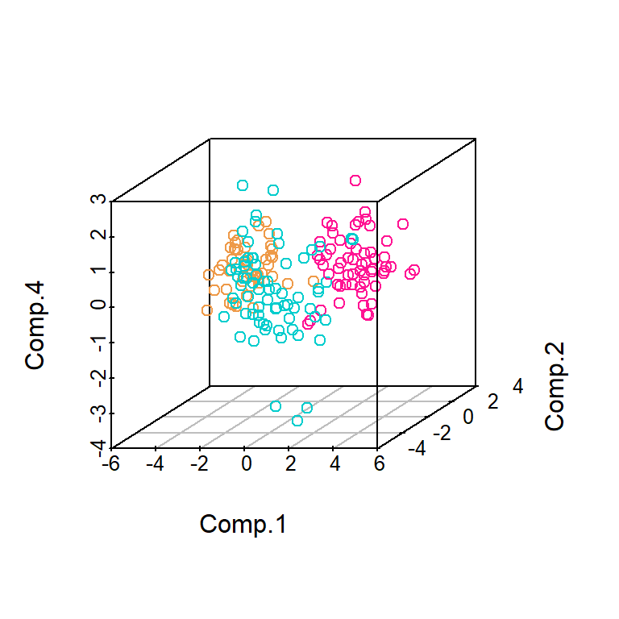

3D Scatter Plot of PCs 1, 2 and 4

```r
d2 <- scatterplot3d(wine.pc$scores[,c(1,2,4)],
              color=c("deeppink1", "cyan3", "tan2")[winedata[,1]])
```

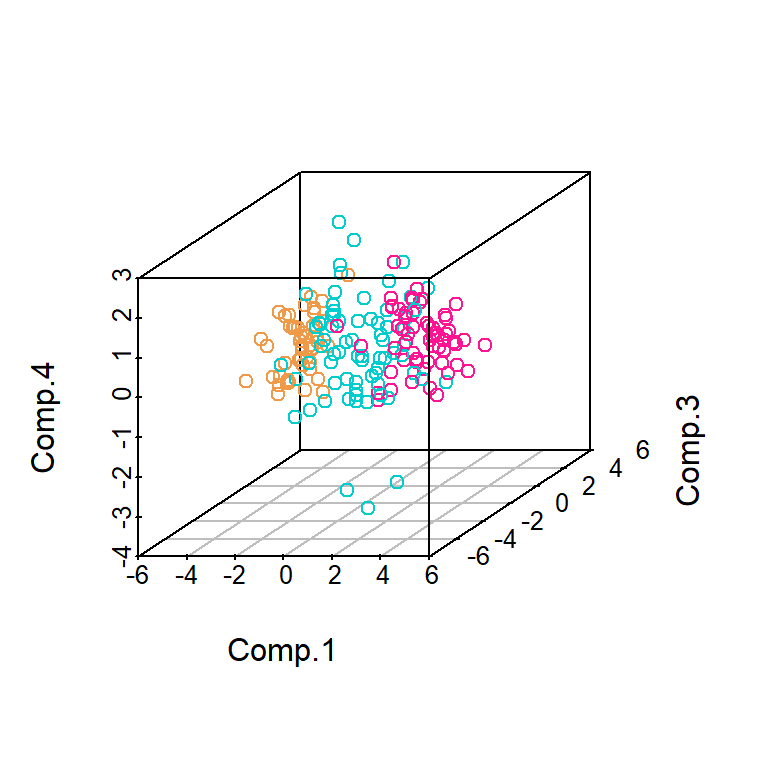

3D Scatter Plot of PCs 1, 3 and 4

```r
d3 <- scatterplot3d(wine.pc$scores[,c(1,3,4)],
              color=c("deeppink1", "cyan3", "tan2")[winedata[,1]])
```

```r
head(wine.pc$loadings[, 1:5])
```

```
##                         Comp.1      Comp.2      Comp.3      Comp.4      Comp.5
## Alcohol            0.144329395  0.48365155  0.20738262  0.01785630  0.26566365
## Malic acid        -0.245187580  0.22493093 -0.08901289 -0.53689028 -0.03521363
## Ash               -0.002051061  0.31606881 -0.62622390  0.21417556  0.14302547
## Alcalinity of ash -0.239320405 -0.01059050 -0.61208035 -0.06085941 -0.06610294
## Magnesium          0.141992042  0.29963400 -0.13075693  0.35179658 -0.72704851
## Total phenols      0.394660845  0.06503951 -0.14617896 -0.19806835  0.14931841
```

# 4 ICA

Independent Component Analysis (ICA) is a technique that allows the separation of a mixture of signals into their different sources, by assuming non Gaussian signal distribution (Yao et al., 2012).

## 4.1 Difrensses between PCA and ICA

Principal Component Analysis (PCA) is a statistical technique used to reduce the dimensionality of a dataset. It aims to compress information by identifying the most important features and combining them into a smaller set of variables. On the other hand, Independent Component Analysis (ICA) is a technique used to separate a multivariate signal into independent, non-Gaussian components. Unlike PCA, ICA does not compress the information, but rather identifies and separates the underlying sources of the signal.

ICA aims to find the linear transformation where the basis vectors are statistically independent and non-Gaussian, while PCA seeks an orthogonal linear transformation maximizing variables’ variance.

## 4.2 FastICA

FastICA is an algorithm that extracts information from complex data by performing independent component analysis. It identifies the independent components and represents the data accurately by finding an orthogonal rotation that maximizes non-Gaussianity.

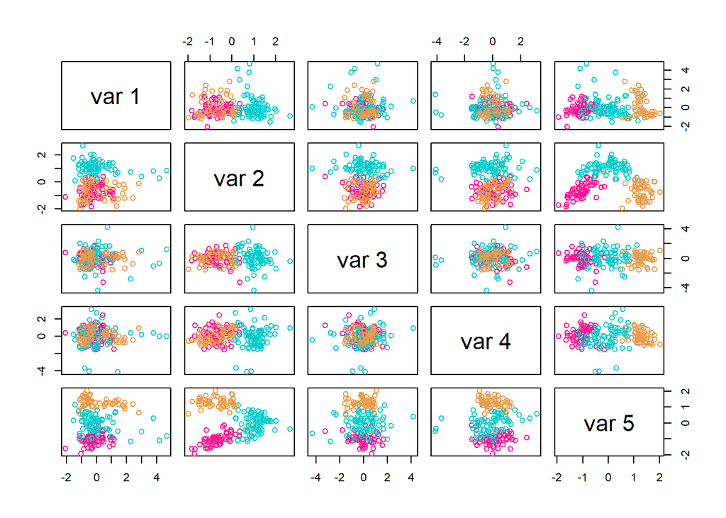

Scatter Plot of 5 PCs - ICA

```r
library(fastICA)
set.seed(777)
wine.ic <- fastICA(wine_s, 5, alg.typ = "parallel", fun = "logcosh", alpha = 1,
method = "R", row.norm = FALSE, maxit=200, tol=0.0001, verbose=TRUE)
pairs(wine.ic$S, col=c("deeppink1", "cyan3", "tan2")[winedata[,1]])
```